# STAT 295 - HW1

Ali Altuntaş, Rubar Akyıldız

2024-04-17

# Question 1:

**i.** Read the data. Change the name of the data for college_score.csv and print the lines 10 through 60.

```r
# wget https://raw.githubusercontent.com/dhavalpotdar/College-Scorecard-Data-Analysis/master/MERGED_2017_2018_cleaned.csv

# mv MERGED_2017_2018_cleaned.csv college_score.csv

# sed -n '10,60p' college_score.csv
```

**ii.** Create a sub-sample of the data set with the following condition: control = Public and city = Montgomery. Add this sub-sample to subsample.csv file.

```r
# head -n1 college_score.csv | cat > subsample.csv
# awk -F, '{if($3=="Montgomery"&&$8=="Public") {print}}' college_score.csv | cat >> subsample.csv
```

**iii.** Obtain the frequencies of each cities.

```r
# cut -d, -f3 college_score.csv | sort | uniq -c
```

# Question 2:

**i.** Read the data set provided in the above URL and assign the name as chocolate. Print the first 6 rows. Examine the structure of the data and comment shortly.

```r
# wget https://raw.githubusercontent.com/rfordatascience/tidytuesday/master/data/2022/2022-01-18/chocolate.csv

chocolate <- read.csv("chocolate.csv")

chocolate %>% head(6)
```

```
##    ref company_manufacturer company_location review_date country_of_bean_origin
## 1 2454                 5150           U.S.A.        2019               Tanzania
## 2 2458                 5150           U.S.A.        2019     Dominican Republic
## 3 2454                 5150           U.S.A.        2019             Madagascar
## 4 2542                 5150           U.S.A.        2021                   Fiji
## 5 2546                 5150           U.S.A.        2021              Venezuela
## 6 2546                 5150           U.S.A.        2021                 Uganda
##   specific_bean_origin_or_bar_name cocoa_percent ingredients
## 1            Kokoa Kamili, batch 1           76%    3- B,S,C
## 2                  Zorzal, batch 1           76%    3- B,S,C
## 3           Bejofo Estate, batch 1           76%    3- B,S,C
## 4            Matasawalevu, batch 1           68%    3- B,S,C
## 5            Sur del Lago, batch 1           72%    3- B,S,C
## 6         Semuliki Forest, batch 1           80%    3- B,S,C
##      most_memorable_characteristics rating
## 1         rich cocoa, fatty, bready   3.25
## 2            cocoa, vegetal, savory   3.50
## 3      cocoa, blackberry, full body   3.75
## 4               chewy, off, rubbery   3.00
## 5 fatty, earthy, moss, nutty,chalky   3.00
## 6 mildly bitter, basic cocoa, fatty   3.25
```

**ii.** Using the some specific command with **pipe-operator,** convert all the characters in your data set into factors.

```r
chocolate <- chocolate %>% mutate_if(is.character,as.factor)

chocolate %>% head(6)
```

```
##    ref company_manufacturer company_location review_date country_of_bean_origin
## 1 2454                 5150           U.S.A.        2019               Tanzania
## 2 2458                 5150           U.S.A.        2019     Dominican Republic
## 3 2454                 5150           U.S.A.        2019             Madagascar
## 4 2542                 5150           U.S.A.        2021                   Fiji
## 5 2546                 5150           U.S.A.        2021              Venezuela
## 6 2546                 5150           U.S.A.        2021                 Uganda
##   specific_bean_origin_or_bar_name cocoa_percent ingredients
## 1            Kokoa Kamili, batch 1           76%    3- B,S,C
## 2                  Zorzal, batch 1           76%    3- B,S,C
## 3           Bejofo Estate, batch 1           76%    3- B,S,C
## 4            Matasawalevu, batch 1           68%    3- B,S,C
## 5            Sur del Lago, batch 1           72%    3- B,S,C
## 6         Semuliki Forest, batch 1           80%    3- B,S,C
##      most_memorable_characteristics rating
## 1         rich cocoa, fatty, bready   3.25
## 2            cocoa, vegetal, savory   3.50
## 3      cocoa, blackberry, full body   3.75
## 4               chewy, off, rubbery   3.00
## 5 fatty, earthy, moss, nutty,chalky   3.00
## 6 mildly bitter, basic cocoa, fatty   3.25
```

**iii.** Obtain some statistics such as mean, standard deviation, median and range of rating values with respect to different company locations. Print only the first 10 observations. Comment some specific statistics shortly from the output.

```r
chocolate %>%  summary()
```

```
##       ref       company_manufacturer company_location  review_date
##  Min.   :   5   Soma     :  56       U.S.A. :1136     Min.   :2006
##  1st Qu.: 802   Fresco   :  39       Canada : 177     1st Qu.:2012
##  Median :1454   Arete    :  32       France : 176     Median :2015
##  Mean   :1430   Bonnat   :  30       U.K.   : 133     Mean   :2014
##  3rd Qu.:2079   A. Morin :  26       Italy  :  78     3rd Qu.:2018
##  Max.   :2712   Dandelion:  25       Belgium:  63     Max.   :2021
##                 (Other)  :2322       (Other): 767
##         country_of_bean_origin   specific_bean_origin_or_bar_name
##  Venezuela         : 253       Madagascar        :  55
##  Peru              : 244       Ecuador           :  43
##  Dominican Republic: 226       Peru              :  41
##  Ecuador           : 219       Dominican Republic:  38
##  Madagascar        : 177       Chuao             :  28
##  Blend             : 156       Venezuela         :  21
##  (Other)           :1255       (Other)           :2304
##  cocoa_percent        ingredients       most_memorable_characteristics
##  70%    :1046   3- B,S,C    :999   creamy, nutty, cocoa:   4
##  75%    : 310   2- B,S      :718   spicy, cocoa        :   4
##  72%    : 295   4- B,S,C,L  :286   cherry, rich choco  :   3
##  65%    :  90   5- B,S,C,V,L:184   sandy, sweet        :   3
##  80%    :  89   4- B,S,C,V  :141   sandy, sweet, cocoa :   3
##  68%    :  72               : 87   sweet, marshmallow  :   3
##  (Other): 628   (Other)     :115   (Other)             :2510
##      rating
##  Min.   :1.000
##  1st Qu.:3.000
##  Median :3.250
##  Mean   :3.196
##  3rd Qu.:3.500
##  Max.   :4.000
##
```

**iv.** Find the chocolates that its review date is equal to 2020 and country of bean origin is equal to Colombia.

```r
colombia <- chocolate %>% filter(review_date == 2020 & country_of_bean_origin == "Colombia")
colombia
```

```
##    ref company_manufacturer company_location review_date country_of_bean_origin
## 1 2466        Crow and Moss           U.S.A.        2020               Colombia
## 2 2534              El Buen           U.S.A.        2020               Colombia
## 3 2482               Finnia           Canada        2020               Colombia
## 4 2478            Kin + Pod           Canada        2020               Colombia
## 5 2498              Odyssey           U.S.A.        2020               Colombia
##   specific_bean_origin_or_bar_name cocoa_percent ingredients
## 1                 Aruaca, batch 39           70%      2- B,S
## 2                           Tumaco           70%      2- B,S
## 3             Chigorodo, batch 001           70%    3- B,S,C
## 4                Tumaco, batch 113           70%    3- B,S,C
## 5                          Arhuaca           70%      2- B,S
##   most_memorable_characteristics rating
## 1                  nutty, citrus   3.25
## 2   cocoa, spice, alcohol, dirty   3.00
## 3          nutty, melon, vinegar   2.75
## 4     poor finish, cocoa, grassy   3.25
## 5        walnut, tobacco, grassy   3.25
```

**v.** Take the mean of chocolate rating and cocoa percent according to the company location.

```r
mean_r <- chocolate %>% aggregate(cbind(rating, cocoa_percent) ~ company_location, FUN = mean)
```

**vi.** Select company manufacturer, company location and country of bean origin **shortly**. Print the first 10 rows of the data frame. (Hint: Please check the column names)

```r
chocolate %>% select(company_manufacturer,company_location,country_of_bean_origin) %>% head(10)
```

```
##    company_manufacturer company_location country_of_bean_origin
## 1                  5150           U.S.A.               Tanzania
## 2                  5150           U.S.A.     Dominican Republic
## 3                  5150           U.S.A.             Madagascar
## 4                  5150           U.S.A.                   Fiji
## 5                  5150           U.S.A.              Venezuela
## 6                  5150           U.S.A.                 Uganda
## 7                  5150           U.S.A.                  India
## 8              A. Morin           France                Bolivia
## 9              A. Morin           France                   Peru
## 10             A. Morin           France                 Panama
```

**vii.** Filter that company location in Switzerland whose rating between 3.25 and 3.5. Take the five observations.

```r
chocolate %>%filter(between(rating,3.25,3.5),company_location == "Switzerland") %>% head(5)
```

```
##   ref company_manufacturer company_location review_date country_of_bean_origin
## 1 508   Beschle (Felchlin)      Switzerland        2010              Venezuela
## 2 508   Beschle (Felchlin)      Switzerland        2010              Venezuela
## 3 508   Beschle (Felchlin)      Switzerland        2010              Indonesia
## 4 508   Beschle (Felchlin)      Switzerland        2010              Venezuela
## 5 636   Beschle (Felchlin)      Switzerland        2011              Venezuela
##       specific_bean_origin_or_bar_name cocoa_percent ingredients
## 1   Carenero S., Barlovento, Grand Cru           70%    3- B,S,C
## 2 Porcelana, Premier Cru, Quizas No. 1           74%    3- B,S,C
## 3                      Java, Grand Cru           64%    3- B,S,C
## 4   Ocumare, Premier Cru, Quizas No. 2           72%    3- B,S,C
## 5 Indigena Amazonia, Grand Cru, Quizas           72%    3- B,S,C
##    most_memorable_characteristics rating
## 1       creamy, macadamia, pepper   3.25
## 2 nutty, light toffee, mild musty   3.25
## 3        ham-like, smokey, banana   3.50
## 4        dark cocoa, spicy pepper   3.50
## 5            creamy, banana, rich   3.50
```

**viii.** What is the mean of the rating column for each company locations find and order by descending.

```r
chocolate %>% group_by(company_location) %>% na.omit() %>% summarise(mean(rating), ordered="decreasing")
```

```
## # A tibble: 67 × 3
##    company_location `mean(rating)` ordered
##    <fct>                     <dbl> <chr>
##  1 Amsterdam                  3.31 decreasing
##  2 Argentina                  3.31 decreasing
##  3 Australia                  3.36 decreasing
##  4 Austria                    3.26 decreasing
##  5 Belgium                    3.10 decreasing
##  6 Bolivia                    3.25 decreasing
##  7 Brazil                     3.28 decreasing
##  8 Canada                     3.30 decreasing
##  9 Chile                      3.75 decreasing
## 10 Colombia                   3.20 decreasing
## # ℹ 57 more rows
```

**ix.** Count that how many observations are assigned Bonnat for each country of bean origin?

```r
chocolate %>% filter(company_manufacturer == "Bonnat") %>% count()
```

```
##    n
## 1 30
```

# Question 3:

**i.** Read data set correctly from the link and called them as nmmaps.Then, examine the relationship between date and temp based on the year. Interpret shortly your plots.

(Hint: You should use facet_wrap)

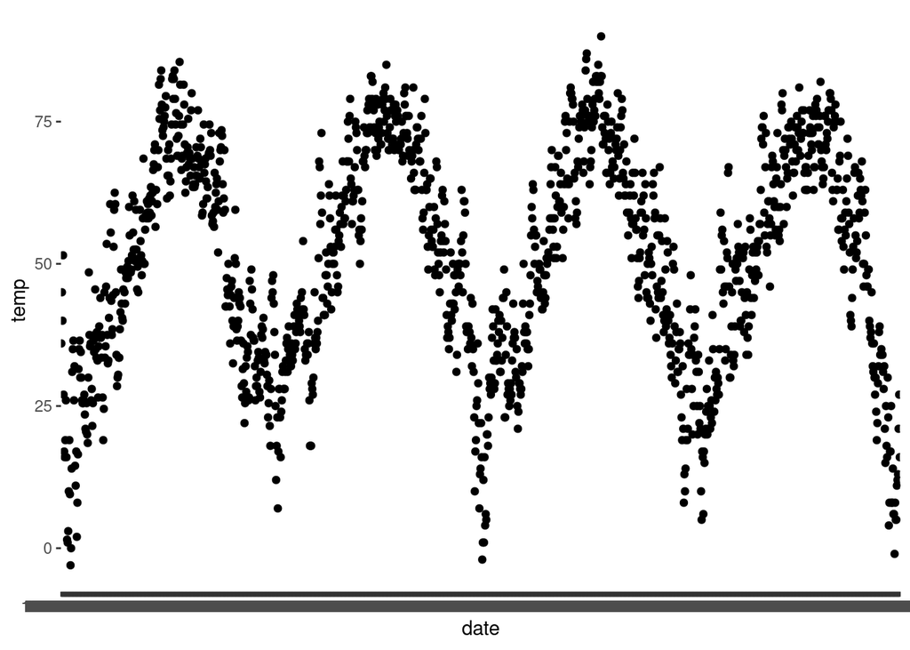

```r
nmmaps <- read.csv('https://www.cedricscherer.com/data/chicago-nmmaps-custom.csv')

nmmaps %>% ggplot(aes(x = date, y = temp)) + geom_point()
```

**ii.** Examine the relationship between date, temp and season. For this question, first specify the factor for season (There are 4 different levels.) Then using geom_point function, examine the relationship and interpret shortly.

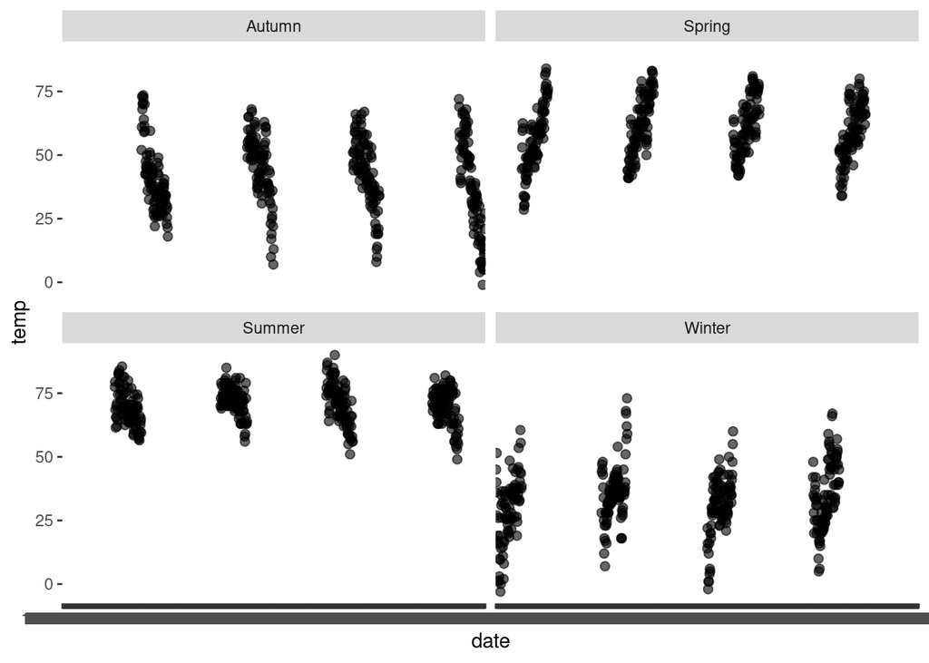

```r
ggplot(nmmaps, aes(x=date,y=temp)) +
  geom_point(size=2,alpha=.6)+
  geom_smooth(method = "lm",se= FALSE)+
  facet_wrap(~season)
```

q4:

```r
battlefields <- read.csv('https://files.planning.data.gov.uk/dataset/battlefield.csv')
battlefields <- battlefields %>% mutate(long_lat = substr(point, start= 7, stop=25))

battlefields <- battlefields %>% mutate(long = substr(long_lat, start= 1, stop=9))

battlefields <- battlefields %>% mutate(lat = substr(long_lat, start= 11, stop=17))

battlefields$long <- as.numeric(battlefields$long)
battlefields$lat <- as.numeric(battlefields$lat)

battlefields %>% leaflet() %>% addProviderTiles("Esri")%>% addMarkers(~long, ~lat, label = ~name, popup = paste0("<b> Name: </b>",battlefields$name,"<br>","<b> Wikipedia </b>", battlefields$wikipedia,"<br>","<b> Wikidata </b>", battlefields$wikidata,"<br>","<b> Document URL: </b>", battlefields$document.url,"<br>","<b> Documentation URL: </b>", battlefields$documentation.url,"<br>")) %>% setView(lng = median(battlefields$long),lat = median(battlefields$lat), zoom = 4.6)
```

[interactive chart not shown]